# Part II - Demographics of Bikers Who Use Ford Bikes

# by Sofiyah Olaiwon

## Investigation Overview

> I am interested in the various characteristics of people who use bikes from the Ford GoBike System. I will be making use of the duration of time spent on the bikes in seconds, the longitude and latitude of both the the start and end stations, the user type, member birth year, member gender and bike share for all trips features to conduct my analysis.

## Dataset Overview

> This document explores a dataset which includes information about individual rides made in a bike-sharing system covering the greater San Francisco Bay area during the month of February.

## Gender Distribution

- Based on the data collected which we have analyzed, in the month of february 2019, 75 percent of the members who took rides are male, 23 percent are female and 2 percent identify as other genders.

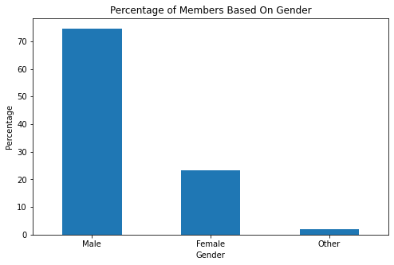

## Member Type Distribution

- A large percentage of GoBike members are subscribers while others are customers and although subscribers constitute more to the data, customers take longer rides on an average than subscribers.

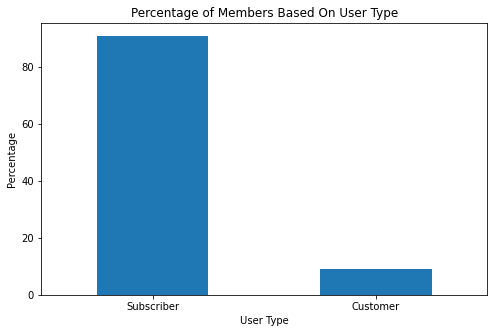

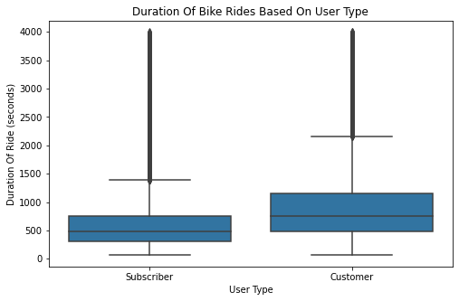

## Age Distribution Of GoBike Members

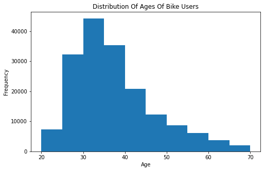

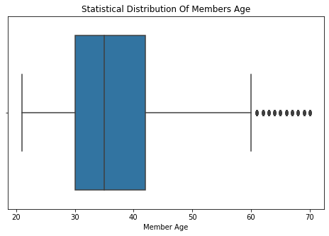